# Kaggle competition

Jun Jie Goh

11/19/2021

#loading data

```r
df <- read.csv("analysisData.csv", stringsAsFactors=FALSE)
scoringData = read.csv('scoringData.csv')
```

# Data cleaning

The first thing I did was to bind the two datasets together so that I can clean them simultaneously. Initially, I cleaned them separately but it was tedious and repetitive. Furthermore, when using xgboost on the scoringData, the columns required the same names and order. Hence, cleaning the data together would be the most pragmatic way of data mining for the two datasets.

#bind data together to clean data simultaneously

```r
combinedf <- bind_rows(df, scoringData)
```

I removed columns that were not required for the analysis. I felt that these columns add no value to the model.

#remove unwanted columns

```r
drop <- c("name", "summary", "space", "description", "neighborhood_overview",
"notes", "transit", "access", "interaction","house_rules", "host_name", "host_about", "host_location",
"host_neighbourhood", "square_feet", "weekly_price", "monthly_price", "host_verifications", "host_has_profile_pic",
"country_code", "smart_location", "country", "state", "street", "require_guest_profile_picutre", "jurisdiction_names",
"calendar_updated")

combinedf <- combinedf[,!(names(combinedf) %in% drop)]
```

When looking at the column ‘property_type’, some count of properties such as Tiny house had a count of lower than 30. I decided to regroup them into the level “other”

#Grouping unique stays and low counts into ‘other’

```r
combinedf$property_type <- recode_factor(combinedf$property_type, Barn = "Other",
                                  Boat = "Other",
                                  Cabin = "Other",
                                  'Camper/RV' = "Other",
                                  Castle = "Other",
                                  Cave = "Other",
                                  Cottage = "Other",
                                  'Dome house' = "Other",
                                  'Earth house' = "Other",
                                  Houseboat = "Other",
                                  Island = "Other",
                                  'Nature lodge' = "Other",
                                  Tent = "Other",
                                  Treehouse = "Other",
                                  'Tiny house' = "Other",
                                  Aparthotel = "Apartment",
                                 'Casa particular (Cuba)' = "Other",
                                  Lighthouse = "Other",
                                 Timeshare = "Other")
```

After doing more exploring on the dataset, I realized that the column amenities could be useful in predicting an AirBnb price.The idea of the code below was to extract and create a new column for the amenities such as TV, wifi, and air conditioning. In addition, the grepl function returns true/false so I used as.interger to ‘hot encode’ the columns. Initially, I wanted to include a lot of amenities, however I realized that my RMSE did not improve or performed worse when I included the commented out code in this section.

After hot encoding the amenities, I dropped the original amenities column because I no longer needed it and it will not fit into the xgboost model.

#Use grepl to extract out amenities and create new column and then drop amenities column

```r
combinedf$TV <- as.integer(grepl("TV", combinedf$amenities))
combinedf$Wifi <- as.integer(grepl("Wifi", combinedf$amenities))
combinedf$Aircon <- as.integer(grepl("Air conditioning", combinedf$amenities))
combinedf$Kitchen <- as.integer(grepl("Kitchen", combinedf$amenities))
combinedf$Heating <- as.integer(grepl("Heating", combinedf$amenities))
combinedf$Gym <- as.integer(grepl("Gym", combinedf$amenities))
combinedf$Washer <- as.integer(grepl("Washer", combinedf$amenities))
combinedf$Dryer <- as.integer(grepl("Dryer", combinedf$amenities))
combinedf$Parking <- as.integer(grepl("parking", combinedf$amenities))
combinedf$Doorman <- as.integer(grepl("Doorman", combinedf$amenities))
combinedf$Hotwater <- as.integer(grepl("Hot water", combinedf$amenities))
combinedf$twentyfourhour <- as.integer(grepl("24-hour check-in", combinedf$amenities))
#combinedf$Essentials <- as.integer(grepl("Essentials", combinedf$amenities))
#combinedf$hottub <- as.integer(grepl("Hot tub", combinedf$amenities))
#combinedf$elevator <- as.integer(grepl("Elevator", combinedf$amenities))
#combinedf$pets <- as.integer(grepl("Pets allowed", combinedf$amenities))
#combinedf$fireplace <- as.integer(grepl("Indoor foreplace", combinedf$amenities))
#combinedf$cable <- as.integer(grepl("Cable TV", combinedf$amenities))


drop1 <- c("amenities")
combinedf <- combinedf[,!(names(combinedf) %in% drop1)]
```

The next thing I did was to look at the true/false columns. I wanted to change them to binary format (1 and 0). I realized this step was not necessary since the function data.matrix will convert them to numerical values when converting the data frame to a matrix. However, I still converted them regardless and anything that has a missing value I filled it with a 0. This approach is similar to the cancellation policy where I ranked them ordinally (flexible as 5 and super_strict_60 as 1).

Looking at the date columns (host_since, first_review, and last_review), I converted them to a numerical feature. I took the date that I was working on the project and deducted it by the date columns to get a numerical value.

I removed percentage signs from host response and acceptance rate so that they will not affect calculations. Subsequently, I replaced missing values with the column mean for security_deposit, cleaning_fee, host_response_rate, and host_acceptance_rate.

```r
#True false to 1 and 0
combinedf <- combinedf %>%
  mutate(host_is_superhost = case_when(as.character(combinedf$host_is_superhost) == "t" ~ 1,
                                      as.character(combinedf$host_is_superhost) == "f" ~ 0,
                                       is.na(combinedf$host_is_superhost) ~ 0)) %>%
  mutate(host_identity_verified = case_when(as.character(combinedf$host_identity_verified) == "t" ~ 1,
                                       as.character(combinedf$host_identity_verified) == "f" ~ 0,
                                       is.na(combinedf$host_identity_verified) ~ 0)) %>%
  mutate(is_location_exact = case_when(as.character(combinedf$is_location_exact) == "t" ~ 1,
                                       as.character(combinedf$is_location_exact) == "f" ~ 0,
                                       is.na(combinedf$is_location_exact) ~ 0))
#Current date minus dates
combinedf <- combinedf %>%
  mutate(host_since = as.integer(as.Date("2021-11-15") - as.Date(combinedf$host_since))) %>%
  mutate(first_review = as.integer(as.Date("2021-11-15") - as.Date(combinedf$first_review))) %>%
  mutate(last_review = as.integer(as.Date("2021-11-15") - as.Date(combinedf$last_review)))

#Ordinal data
combinedf <- combinedf %>%
  mutate(cancellation_policy = case_when(combinedf$cancellation_policy == "flexible" ~ 5,
                                         combinedf$cancellation_policy == "moderate" ~ 4,
                                         combinedf$cancellation_policy == "strict_14_with_grace_period" ~ 3,
                                         combinedf$cancellation_policy == "super_strict_30" ~ 2,
                                         combinedf$cancellation_policy == "super_strict_60" ~ 1))

#remove % from host response rate and host acceptance rate
combinedf$host_response_rate <- gsub("%","",combinedf$host_response_rate, fixed = TRUE) %>%
  as.numeric()
combinedf$host_acceptance_rate <- gsub("%","",combinedf$host_acceptance_rate, fixed = TRUE)%>%
  as.numeric()
#Replacing missing values with mean
combinedf$security_deposit[is.na(combinedf$security_deposit)] <- mean(combinedf$security_deposit, na.rm=TRUE)
combinedf$cleaning_fee[is.na(combinedf$cleaning_fee)] <- mean(combinedf$cleaning_fee, na.rm=TRUE)
combinedf$host_response_rate[is.na(combinedf$host_response_rate)] <- mean(combinedf$host_response_rate, na.rm=TRUE)
combinedf$host_acceptance_rate[is.na(combinedf$host_acceptance_rate)] <- mean(combinedf$host_acceptance_rate, na.rm=TRUE)
```

When looking at the geographical features, I decided to use neighborhood, neighborhood_cleansed, neighbourhood_grouped_cleansed, city, and zipcode as my features. For the neighbourhood and city columns, I removed all punctuation, internal spaces, and converted them to lower cases to standardize their format for analysis. In addition, if the neigbourhood and city frequency does not occur more than 10 times, I will remove them from the analysis.

```r
# clean neighbourhood and neighbourhood cleansed
combinedf$neighbourhood<-gsub(",|-|\\n|\\)|\\(|/|\\.", " ",combinedf$neighbourhood)
combinedf$neighbourhood <- tolower(combinedf$neighbourhood)
combinedf$neighbourhood <- str_trim(gsub("\\s+", " ", combinedf$neighbourhood))
combinedf$neighbourhood <- fct_lump_min(combinedf$neighbourhood, min=10)
combinedf$neighbourhood <- as.factor(combinedf$neighbourhood)

combinedf$neighbourhood_cleansed<-gsub(",|-|\\n|\\)|\\(|/|\\.", " ",combinedf$neighbourhood_cleansed)
combinedf$neighbourhood_cleansed <- tolower(combinedf$neighbourhood_cleansed)
combinedf$neighbourhood_cleansed <- str_trim(gsub("\\s+", " ", combinedf$neighbourhood_cleansed))
combinedf$neighbourhood_cleansed <- fct_lump_min(combinedf$neighbourhood_cleansed, min=10)
combinedf$neighbourhood_cleansed <- as.factor(combinedf$neighbourhood_cleansed)

combinedf$neighbourhood_grouped_cleansed <- tolower(combinedf$neighbourhood_group_cleansed)
combinedf$neighbourhood_grouped_cleansed <- as.factor(combinedf$neighbourhood_group_cleansed)

combinedf$city<-gsub(",|-|\\n|\\)|\\(|/|\\.", " ",combinedf$city)
combinedf$city <- tolower(combinedf$city)
combinedf$city <- str_trim(gsub("\\s+", " ", combinedf$city))
combinedf$city <- fct_lump_min(combinedf$city, min=10)
combinedf$city <- as.factor(combinedf$city)

combinedf$zipcode <- gsub("[^\\d]", "", combinedf$zipcode, perl=TRUE)
combinedf$zipcode <- substr(combinedf$zipcode, 1, 5)
combinedf$zipcode[nchar(combinedf$zipcode)<5] <- NA_character_
combinedf$zipcode <- as.factor(combinedf$zipcode)
combinedf$zipcode <- fct_lump_min(combinedf$zipcode, min=5)
```

After cleaning my data, I split them back into my the original data and scoringData. They are differentiated by price. The scoring data does not contain any price column so they can be easily separated.

```r
df <- combinedf[!is.na(combinedf$price),]
scoringData <- combinedf[is.na(combinedf$price),]
```

#drop remainding missing values

```r
#drop null values
df <- df %>% drop_na()
```

#Test train split

```r
set.seed(1031)
split = createDataPartition(y = df$price,
                            p = 0.7,
                            list = F,
                            groups = 100)

train1 = df[split,]
test1 = df[-split,]
```

# XGBoost model

Before building my model, I need to convert both my test/train split dataframes into a xgb.Matrix. I have removed the price column in the data argument while specify price for the label.

```r
xgb_train = xgb.DMatrix(data =  data.matrix(subset(train1, select = -c(price) )), label =  data.matrix(subset(train1, select = c(price))) )

xgb_test = xgb.DMatrix(data =  data.matrix(subset(test1, select = -c(price))), label =  data.matrix(subset(test1, select = c(price) )))
```

Build XGBoost on training data with 200 trees

```r
xgboost = xgboost(data=xgb_train,
                  #label = train1$price,
                  nrounds=200,
                  verbose = 0,
                  early_stopping_rounds = 30)



#pred train
pred_train = predict(xgboost,
                    newdata=xgb_train)

rmse_train_xgboost = sqrt(mean((pred_train - train1$price)^2));rmse_train_xgboost
```

```
## [1] 29.07652
```

Predict on test set. Note here we are clearly overfitting the model. I am unsure of how to prevent overfitting at this stage.

```r
#pred test
pred = predict(xgboost,
               newdata=xgb_test)


rmse_xgboost = sqrt(mean((pred - test1$price)^2)); rmse_xgboost
```

```
## [1] 60.71271
```

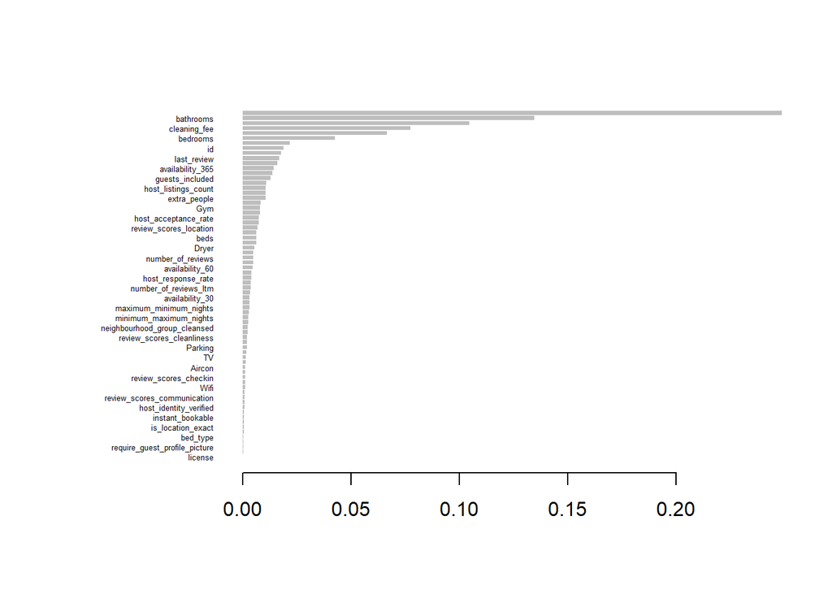

```r
importance_matrix <-xgb.importance(colnames(xgb_train), model = xgboost)
xgb.plot.importance(importance_matrix)
```

# Tune Model

I used k-fold cross validation to tune the parameter of my model.

```r
param <- list(
      booster = "gbtree"
    , eta = 0.1
    , max_depth = c(6,7,8,9)
    , min_child_weight = c(1,2)
    , subsample = 1
    , objective = "reg:squarederror"
    , eval_metric = "rmse"
      )

cv.nround = 1000
cv.nfold = 5

cv <- xgb.cv(data=xgb_train, params = param, nthread=6,
                nfold=cv.nfold, nrounds=cv.nround,
                verbose = T,early_stopping_round = 20, maximize = F)
```

```r
cvxgboost = xgboost(data=xgb_train,
                  params = param,
                  nrounds=1000,
                  verbose = 0,
                  early_stopping_rounds = 20)

cvxgboost$best_iteration
```

```
## [1] 1000
```

```r
#pred train
cv_pred_train = predict(cvxgboost,
                    newdata=xgb_train)

rmse_train_cv_xgboost = sqrt(mean((pred_train - train1$price)^2));rmse_train_cv_xgboost
```

```
## [1] 29.07652
```

```r
pred = predict(cvxgboost,
               newdata=xgb_test)


rmse_xgboost = sqrt(mean((pred - test1$price)^2)); rmse_xgboost
```

```
## [1] 59.28523
```

# predict best model

```r
# pred123 = predict(cvxgboost,newdata= xgb.DMatrix(data.matrix(subset(scoringData, select = -c(price) ))))
```